# Become a UseR: a brief tour in R

# Programming a function in R

- In R programming, a function is a set of instructions that performs a specific task.
- R offers a large number of built-in functions; moreover, it is possible to create or customize functions too.
- Generally, a function uses one or more argument part as inputs, then it processes arguments in the body part, and finally, it may return an output.
- A rule of thumb is that if you are performing a task three or more times, you should write a function for that task.

## Programming a function in R

The standard syntax to create a function generally looks like the following example:

```
function_name <- function(arg_1, arg_2, arg_3){

    statements_to_be_processed

    return(output_variable_name)
}
```

## Programming a function in R

```r
# Assign square to a function with one argument, x
square <- function(x)
    {
       sqr <- x^2

       return(sqr)
    }
```

A few points to note:

- The name of the function is `square` which is on the left hand side of the assignment
- The function called `square` takes one argument, called `x`.
- The block of code to be executed when the `square` function is called is enclosed in curly braces(`{}`).

## Programming a function in R

```r
# Use function square
square(11)
```

```
## [1] 121
```

# Reading data in R

One of the first steps in any data analysis project is to read data from a file. Data can come in myriad forms, but the most common and convenient form is the spreadsheet.

Assuming that your data is in a text file, R provides essential reading functions to turn a text file into a data frame according to a delimiter (or field separator).

| Functions | Delimiter |
| --- | --- |
| `read.csv()` | comma |
| `read.csv2()` | semicolon |
| `read.fwf()` | arbitrary fixed width |
| `read.delim()` | tab |
| `read.table()` | customizable delimiter |

# Packages in R

A package is a bundle of R functions, documentation, tests and sometime data sets. They are usually developed to add specific functionality.

- To add a a package in your library, run the `install.packages()` function, such as:

```
install.packages("xlsx")
```

- To load a library, use the function `library()`:

```
library(xlsx)
```

https://cran.r-project.org/web/packages/

# Bioconductor

“The Bioconductor mission is to promote the statistical analysis and comprehension of current and emerging high-throughput biological assays.”

“Most Bioconductor components are distributed as R packages. The functional scope of Bioconductor packages includes the analysis of DNA microarray, sequence, flow, SNP, and other data.”

*Ref: https://www.bioconductor.org*

# Basic statistical analysis example

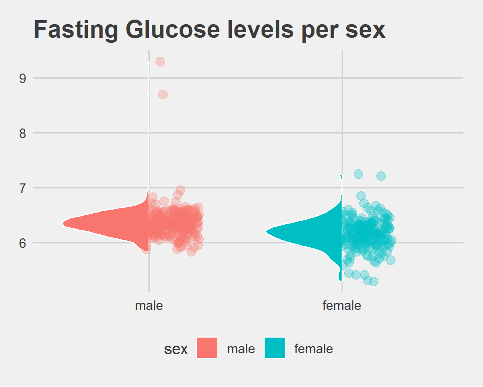

# Conclusion

**Pros of R Language**

- R is an open-source.
- R is cross-platform which runs on many operating systems.
- R has a large community and open-source resources
- R offers vast visualization and interactive tools
- New technology and ideas often appear first in R.

**Cons of R Language**

- The quality of some packages in R is less than perfect.
- There is no customer support of R Language if something does not work.
- Designed for interactive data analysis; very large data sets and computation may require addition adjustment.

# Resources

- [Learning R resources link](https://github.com/OSGA-OPAR/quant-genetics-webinars/blob/master/2021-03-12/Resources.md)